# Critical citation practice

Rob Davies

## We are learning how to think critically for ourselves

*Active learning* works best even if it sometimes feel challenging

- Active learning is what you do when you ask or answer questions
- We will prompt you sometimes with Activate

**Activate**

How do you decide to cite a source?

## Our plan

**What we can do**

1. Overview: what we are doing when we cite scholarly work
2. What people do, and what they say they are doing
3. Revisiting being and doing science: focus on peer review, critical discourse, and the response to error
4. The idea that science is self-correcting and the reality

## This topic *should* be boring

- Citation practice should be a boring topic for discussion
  - but it provides a fascinating window into how science works
- Reflection will show us that we must ask ourselves important ethical questions when we engage in our own citation practice
  - We will return here to our account of how science is done

## Maybe this bit *is* boring

Guidance to students on making citations typically focuses on the formatting of citations and reference lists

[figure not shown]

Association (2020): The APA 7 manual

## Maybe this bit *is* boring

Guidance to students on making citations typically focuses on the formatting of citations and reference lists

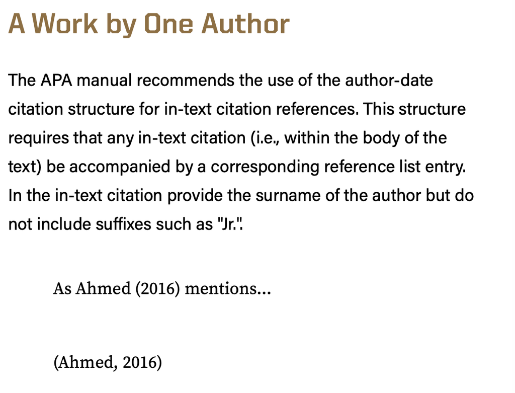

We often instruct students on formatting requirements with no explanation of what we are doing or why

https://owl.purdue.edu/owl/research_and_citation/apa_style/apa_formatting_and_style_guide/in_text_citations_author_authors.html

## Automate the boring stuff

Guidance to students *should* minimise the effort required to ensure compliance with the rules

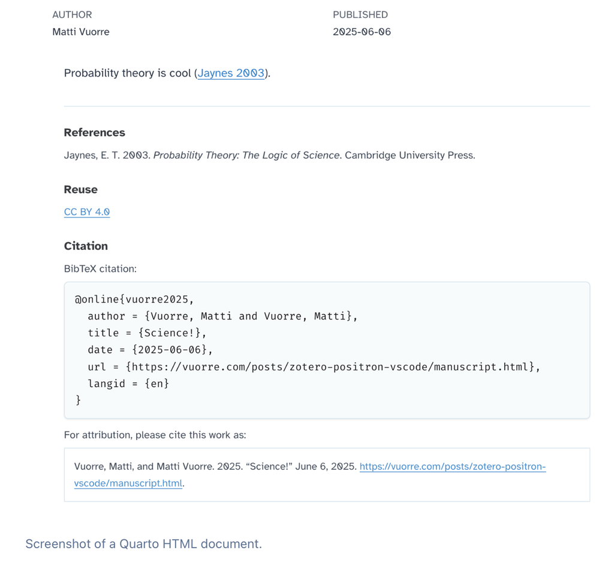

I *automate* citation and reference list formatting as far as possible using Zotero in Quarto

https://vuorre.com/posts/zotero-positron-vscode/

## Guidance is typically practice-based and rarely explained

- You should include these sources [x]
  - Because they are authoritative or seminal $\rightarrow$ what does that mean?
  - Because you are criticizing or otherwise building on that work $\rightarrow$ why and how?
  - Because you are acknowledging an intellectual or a technical debt $\rightarrow$ where, when, why and how?

## Why this is worth thinking about

- We should develop a critical citation practice:
  - Because giving and receiving citations is essential to how we have been doing science lately
  - Because, for scientists
    - Giving and receiving citations is argued to count as a unit of exchange in a *credit economy*
    - Citation data are how science and how scientists are evaluated

## What we will need to think about

- Science as a credit economy
  - Who does or does not get credit
  - Ideas about authorship, contributionship and priority
- Science as a self-correcting process or system or culture
- Citations as data for evaluating science and scientists

## Critical reflection may help us to answer questions we need to ask ourselves when we work

**Exercising personal responsibilities**

- How do we proceed in a manner that is reflective or self-aware in ways that are useful or helpful to ourselves and others?
  - In our work as scholars or students or teachers or practitioners?
- Looking ahead to our role as citizens of science, with the corresponding ethical responsibilities
  - How do we break free of the biases or inequities or limitations that citation analyses appear to reveal?

## Activate

Overview — our learning questions then are these:

**Activate**

- When, why, and how do you do scholarly citation?
- How do you develop an ethical citation practice?

## What are the reasons for citations?

**The reasons**

- We will look at what people say they are doing when they do citations
- We will look again at persuasive language devices, including the *misuse* of citations

## Surveys of citation behavior

Case & Higgins (2000) survey researchers who cited the works of two famous authors in the communication literature:

- Few citing authors responded but they identified reasons for citing the authors as including:
  - The reference reviews prior work in this area
  - The reference is a ‘concept marker’
  - The reference documents the source of a method or design feature
  - The cited work is novel, well known, and represents a genre of studies

## Surveys of citation behavior

Case & Higgins (2000) survey researchers who cited the works of two famous authors in the communication literature:

- Because of the citing author’s judgment that citing a prestigious work will promote the cognitive authority of *their* work
- Because of the perception that a cited item deserves criticism
  - Making the citation identifies the citer as a critical thinker

## A taxonomy of motives to cite

- Surveys are limited by memory and self-interest so Erikson & Erlandson (2014) derive a taxonomy of motives from reviews of the philosophical and empirical evidence:
  - Citations may have many purposes for the citing author
    - Argumentation, Social Alignment, Mercantile Alignment, and Data

## A taxonomy of motives to cite

- Argumentation – to support an argument
  - Delimitation
    - To explicitly position the work in relation to various methodological and/or theoretical approaches
  - Active support
    - To show that others share your opinion, or that your arguments follow from the writings of others
  - Active criticism
    - Identifying problems with previous work, as a rationale for a study

## A taxonomy of motives to cite

- Social alignment – as a way for the author to present themselves
  - To indicate identification with a scientific tradition
  - To present an image of who the author is in relation to the tradition (*as* mainstream or iconoclastic or eclectic)
  - To signal effort

## A taxonomy of motives to cite

- Mercantile alignment – to gain credit
  - Giving credit to other people’s work
  - To show a reader that the author knows the subject
  - As a form of barter (hoping for reciprocation)
  - As self-promotion
  - Pledging, as an attempt to make the right impression by referencing theories or authors or by signalling thoroughness

## Citations as a form of communication

- Citation practice is based on authors’ beliefs about readers’ expectations and cognition
  - Possible readers include cited authors, reviewers, editors, colleagues, opponents, funders …

## If citations are used partly to persuade then they are persuasive communication devices

- Corneille et al. (2023) reflect on their writing practices and experiences of writing:
  - Authors rely on a range of *devices* and techniques to attract and maintain the interest of readers
  - to convince readers of the merits of the author’s point of view

## Citations can be misused

1. Ignoring previous work
- Not citing previous work that decreases the perceived novelty of the current work
2. One-sided citation
- Mostly or only citing supportive research, and mostly or completely ignoring research that does not support the author’s point of view

## Citations can be misused

3. Reliance on weak evidence
- Citing work that is now known to be weak or wrong
4. Misleading use of references
- Citing papers that are not relevant to the point the author is trying to make
- to give the impression that support for this point is stronger than it actually is

## Persuasive communication devices

5. Missing evidence
- Making statements that are not backed up with citations
6. Reliance on precedent
- Suggesting that a procedure with known flaws is ok because it has been used in lots of previous studies
7. Reliance on number of citations
- Arguing that because previous work has received lots of citations, it is important and high quality

## Activate

Our learning question is this:

**Activate**

- What or who are you thinking about when you cite previous research in your scholarly writing?

## Developing our understanding further: being and doing science

**What we can do**

- Developing our understanding further:
  - Being and doing science
  - Peer review and critical discourse

## What is going on: Why do people act like this?

- We can consider the following interconnected things:
  - Science as a credit economy
    - Who gets credit, and ideas about authorship, contributionship and priority
  - Peer review as a (flawed) means of evaluating science
  - Citations as a means of evaluating science and scientists

## The importance of priority

Merton (1957): institutional norms exert pressure on scientists to exert their claims

- Disputes over *priority* go back a long way— why?

> numerous scientists, both great and small, have engaged in … acrimonious controversy

## The importance of priority

Merton (1957):

- Scientists are supposed to advance knowledge to the fullest extent possible
- Recognition and esteem are supposed to accrue to those who have done this effectively
- Recognition for originality becomes socially validated testimony and permits a form of ownership over ideas
  - And yet we are also supposed to acknowledge our indebtedness to the legacy of knowledge from our predecessors

## Science as a credit economy

- Models of how scientists operate assume that scientists seek *credit* (Bright, 2017)
  - Selfish credit-seeking behaviour by scientists inadvertently promotes socially beneficial epistemic outcomes
- We can think alternatively in terms of the *natural selection* of certain behaviours (Smaldino & McElreath, 2016; Smaldino & O’Connor, 2022)

## Science as a credit economy and authorship

**Important**

- You and your ideas are *not* going to get credit *without* publication *and* consequently the public identification of your authorship

## Science as a credit economy and authorship

- *Given* a record of publications
- *Given* a a citation index (Garfield, 1955)
  - We can track the *impact* of work on literature and thinking $\rightarrow$ impact factor
  - But who gets the credit? We need to consider questions of authorship or contributorship?

## Scientific authorship

Larivière et al. (2021):

> Scientific authorship is regularly considered as the primary currency in academia, whether for hiring, promotions or priority disputes

## Scientific authorship

Larivière et al. (2021): We see increasing numbers of authors per article over time but who did what?

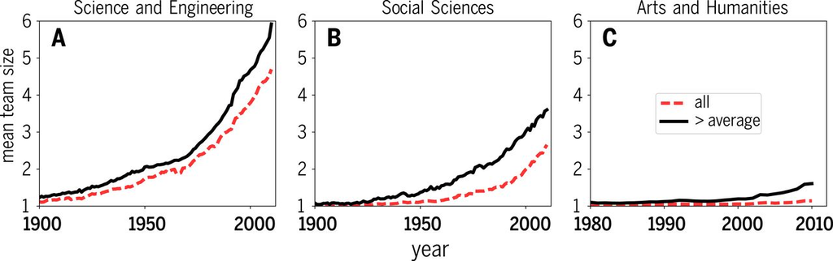

Fortunato et al. (2018): The red dashed curves represent the mean number of coauthors over all papers; the black curves consider just those papers receiving more citations than the average for the field. Black curves are systematically above the dashed red ones, meaning that high-impact work is more likely to be produced by large teams

## Credit where credit is due

Allen et al. (2014): *CRediT* — We can move beyond ‘authorship’ as a dominant measure of esteem

- Researchers should be able to describe what they contributed
  - To distinguish their skills
  - So that junior researchers can gain credit
  - So methodological innovators can make their roles apparent

## Documenting contributions to scholarly articles using CRediT

- Different members of the team usually have different roles (Holcombe et al., 2020): `CRediT`
- Contributorship: we should document the nature of each researcher’s contribution

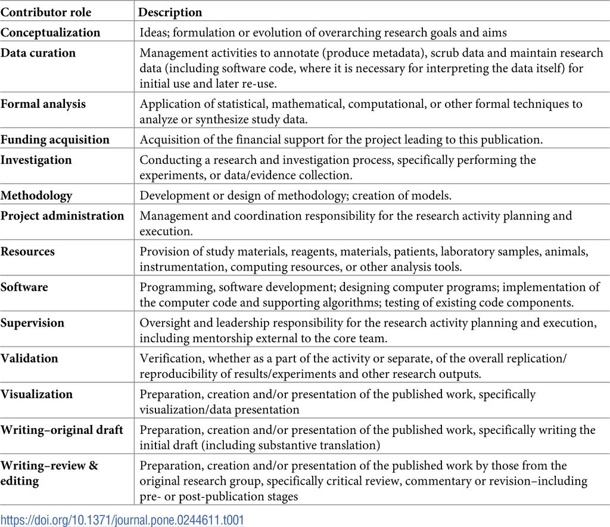

Holcombe et al. (2020): `CRediT` taxonomy

## Documenting contributions to scholarly articles using CRediT

Holcombe et al. (2020): `CRediT` the Contributor Role Taxonomy

- Ideally, authors will arrive at a consensus regarding who did what
- Would be wise to agree contributions using `CRediT` and tools like `tenzig` at the beginning of a project

https://sfdora.org/resource/tenzing/

## Documenting contributions to scholarly articles using CRediT

Holcombe et al. (2020): `CRediT` is not a good fit for all fields or for all projects

- We need to think carefully about forms of research (e.g., systematic reviews) that may draw on contributions from people who have not traditionally been included in author lists (e.g., specialist librarians)
  - Ward-Fear et al. (2020): nonprofessional scientists should be credited as authors under a collective identity (‘group coauthorship’)

## Questionable authorship practices

Larivière et al. (2021):

- Ghost authorship: omission of a researcher who contributed significantly to the project
- Ghost management: omission of management by corporate entities
- Guest authorship: identifies prestige names as authors
- Gift authorship: includes people as authors without corresponding contribution

## Analyses of contributions:

Larivière et al. (2021) analyzed contributorship information for papers published in PLOS in 2017-18:

- Majority of authors contribute to: writing—review and editing (68%); methodology (55%); investigation (53%); and conceptualization (51%)
- Other CRediT contributions performed by a minority of authors
  - Analyses reveal gender gaps in who does what:
    - Women more likely to have written the original draft
    - Men more often associated with senior tasks

## Activate

Our learning question then is this:

**Activate**

- If you are involved in research, what things *should* require the identification of your contribution in a CRedIT statement?

## How does scientific work get to the public?

**What we can do**

- *If* your authorship or contributionship or priority is important
- *How* then does the work you authored or contributed to get to print so that the credit can be transferred?
  - We need to revisit ideas about being or doing science
  - To deepen and question our account of the peer review process

## Communism, universalism, disinteredness, organized skepticism

- Recall Merton (1942): the *ethos* of modern science includes
  - **Communism:** make your work freely available to others, and open to evaluation
  - **Universalism:** evaluate ideas independent of who their sources are
  - **Disinterestedness:** evaluate ideas based on evidence or reason, not preferences or interests
  - **Organised skepticism:** suspension of judgment, openness to being wrong

## The normal business of science: solving puzzles

- Most of the time, scientists, working as members of a community or a tradition, work within a *shared understanding* (Kuhn, 1970) of:
  - What problems are worth investigating
  - What solutions are possible
  - What methods can be used

**Activate**

You cannot question everything all the time but *when must* you question things?

## Communities in which critical perspectives are necessary and useful

Longino (2026): the social dimensions of scientific knowledge

- We need free and open discussion of ideas because no-one is perfect and critical discussion should help us to avoid false or partial (personally biased) beliefs (Mill, 1859)
- In practice, this work could progress through the efforts of scientists to test each others’ theories (Popper, 2005)
- As individuals, alone, we cannot get to the truth but we can as a community agree on consensus understandings that will ultimately converge on the truth (Pierce, 1878/1958)

## Evaluation of quality, relevance, and interest (novelty or utility)

- How should we evaluate the quality, relevance, interest (novelty or utility) of research?
- In the last few decades, we have mostly relied on *peer review*
- What is peer review and how does it work?

## What is peer review?

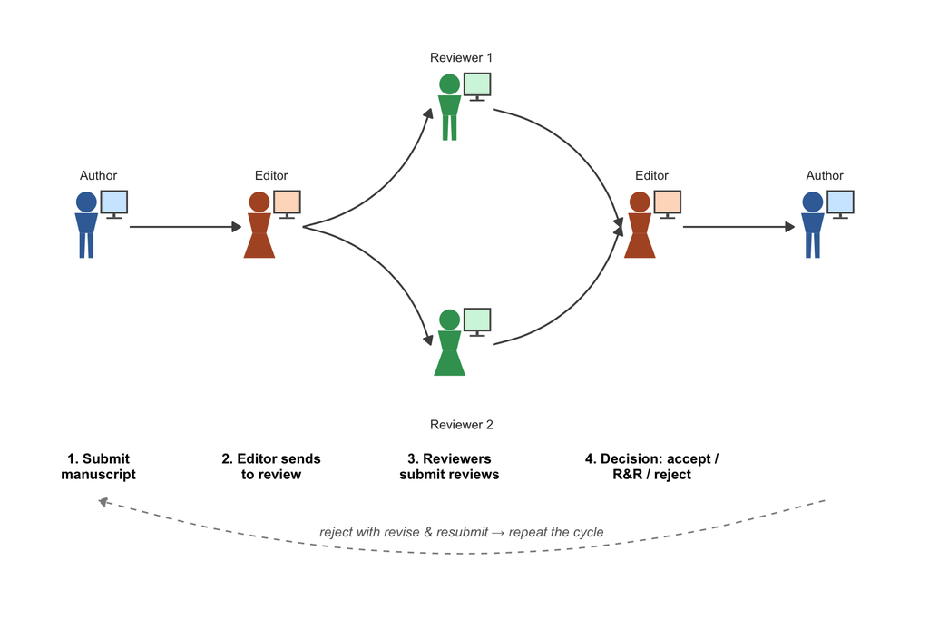

Figure 1: The peer-reviewed publication cycle — a *simplified* representation: submission, review, and decision, repeating until accept or reject

## How does peer review work? Evaluation and feedback

Aczel et al. (2021): In their peer reviewer role, scientists and other researchers *volunteer* to

- Provide comments to improve other researchers’ manuscripts and judge their quality
- Use their *unpaid* (salaried) time and (usually) expert knowledge to provide detailed evaluation and suggestions for improvement

## How does peer review work? Voluntary but expensive

An analysis by (Aczel et al., 2021) estimates high costs:

- Total time reviewers globally worked on peer reviews was over 100 million hours in 2020
- Estimated monetary value of the time US-based reviewers spent on reviews was over 1.5 billion USD in 2020
- For China-based reviewers, the estimate is over 600 million USD
- For UK-based, close to 400 million USD

## Journal prestige matters

> … successful publication in [prestigious] journals is treated as a quality signal in hiring, promotion and funding decisions …

(Brembs, 2018; see also Brembs et al., 2013)

**Tip**

Journal ranking is commonly assessed using impact factor (IF): metric loosely based on citations

## Peer review works as a quality filter?

Researchers have submitted fake articles including errors to journals for review (Mastroianni, 2022):

- 199 peer reviewers failed to identify most major errors (Baxt et al., 1998); identified more errors if recommended rejection or revision; missed that conclusions not supported
- 221 reviewers missed most errors (Godlee et al., 1998); blinding author identity or requiring reviewer signature had no effect
- 607 reviewers missed most errors, including missing randomization (Schroter et al., 2008)

## Peer review works as a quality filter?

Bakker & Wicherts (2011; similar results in Nuijten et al., 2016) checked the the consistency of reported test statistics, degrees of freedom, and p values in 281 psychology articles:

- Estimate 18% of statistical results in the psychological lifterature are incorrectly reported
- 15% of the articles contained at least one incorrect statistical conclusion (after recalculation)
- Errors were often in line with researchers’ expectations
  - Automated statistical checking could identify errors before publication (Nuijten & Wicherts, 2024; Vazire & Holcombe, 2022)

## Unclear that higher ranking journals are more reliable

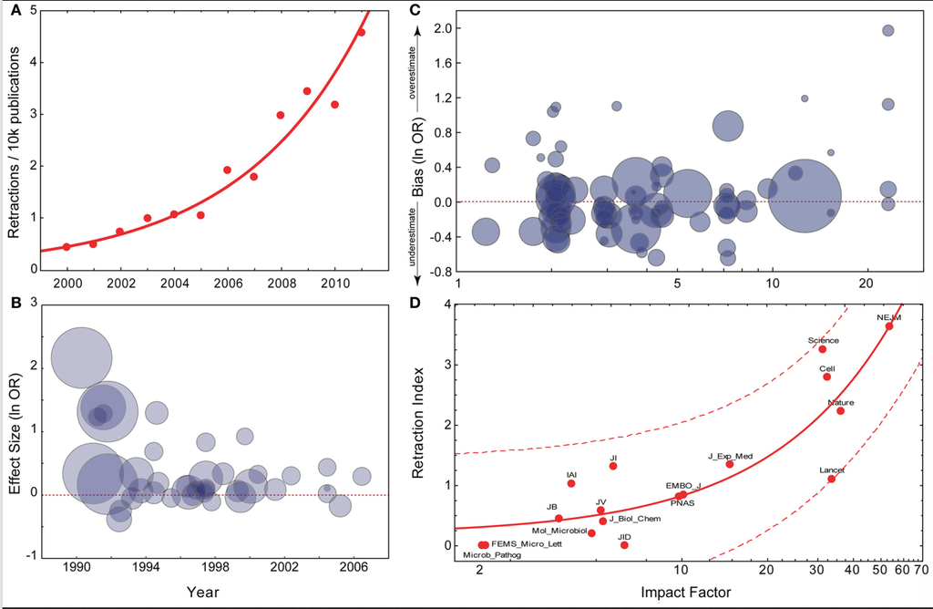

Brembs et al. (2013): (A) retraction notices (B) effect size by date (C) IF versus effect overestimation (D) IF versus retraction index

## Peer review is imperfect but maybe it is the best system we have (for now)

There have been consequential errors: the false claim that MMR vaccination results in Autism Spectrum Disorder

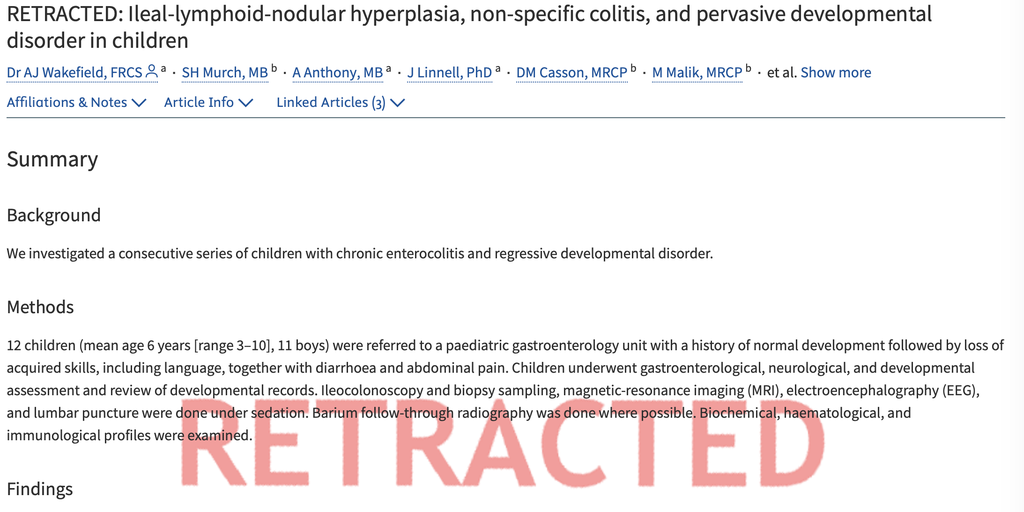

Deer (2011) exposes the bogus data behind the claims made in the *retracted* Wakefield et al. (1998) article falsely claiming a link between vaccination and Autism

## The problem with peer review is *the peers*

Andrew Gelman argues:

- Consider *who* actually does the work of reviews
- Why or how flawed papers don’t get retracted
- The potential utility of alternatives

https://statmodeling.stat.columbia.edu/2020/06/11/bla-bla-bla-peer-review-bla-bla-bla/

## Entities enabling scientific fraud at scale are large, resilient, and growing

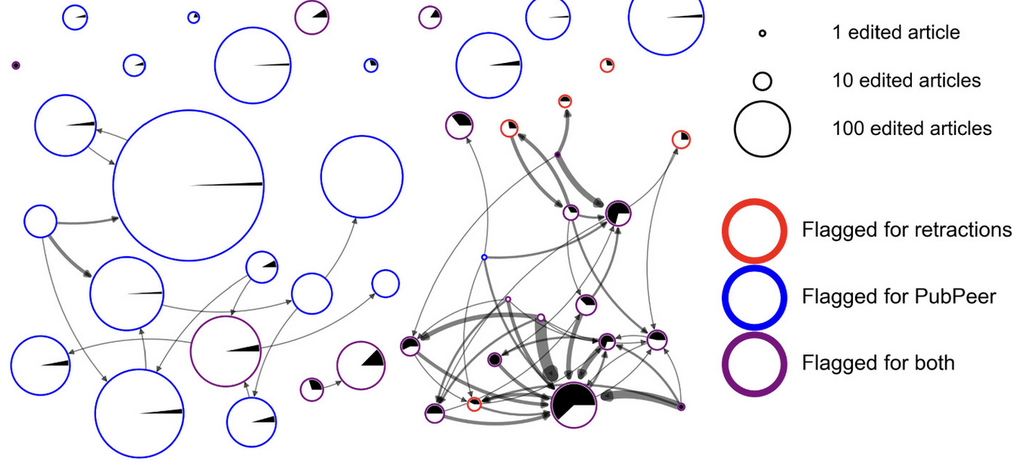

(Richardson et al., 2025) flagged individuals handle each others’ submissions

## Is Peer Review a Good Idea?

(Heesen & Kofi Bright, 2021) argue that prepublication peer review should be *abolished* – they propose to:

- Move the date of publication so that an article is published before it enters peer review because
  - Peer review is expensive
  - It has uncertain success as a quality control mechanism
  - No evidence of epistemic benefits across a range of evaluative criteria
    - Heesen & Kofi Bright (2021): we should enable selection for long-term credit versus short-term (*IF*) credit

## ArXiv and the turn to preprints

ArXiv emerges out of a culture (in Physics) of circulating preprints (Shalizi, n.d.)

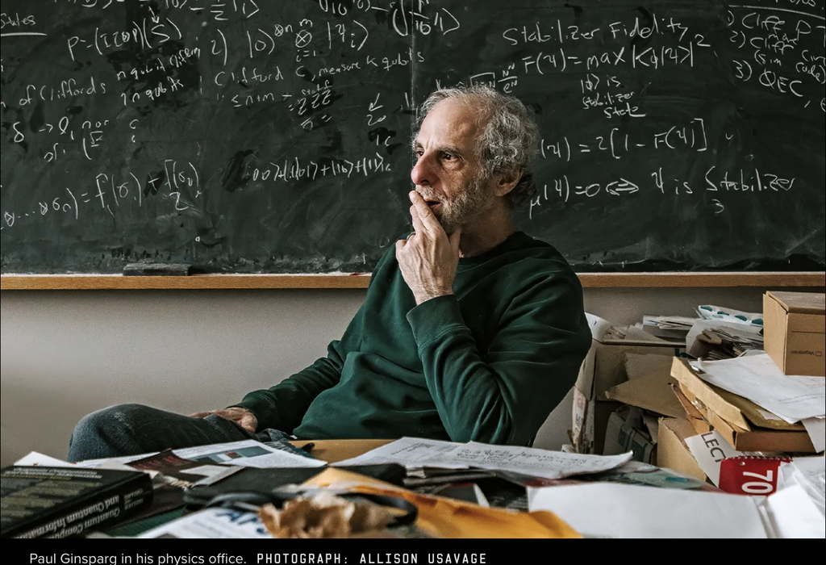

Wired: Paul Ginsparg, creator of `ArXiv`

## If peer review did not exist, would we have to invent something like it?

Maybe (Heesen & Kofi Bright, 2021; Shalizi, n.d.) peer review provides:

- Some (minimal) guarantee to outsiders
  - At least one external reviewer
- A means to mitigate runaway Matthew effects
  - When already famous authors gain outsize credit
- A practical means to filter attention
  - World-without-referees means more work to be done by individuals, but a lot will be redundant

## How do Psychology journals handle postpublication critique?

Whamond et al. (2025) report a cross-sectional study of journal policy and practice:

- Postpublication critique may be an important mechanism of scientific self-correction
  - But few Psychology journals allow it
  - Critiques are rarely published

## Pre- and post-publication peer review

- **Pre-publication peer review**: review of a manuscript, intended for publication, where publication withheld until one or more editors decide that manuscript passes peer review
- **Post-publication peer review**: publish or preprint research; receive questions or responses; update

**Tip**

Here’s a nice example of post-publication review:

https://wellcomeopenresearch.org/articles/6-126

## Activate

Our learning questions then are these:

**Activate**

- How well does peer review work as a process for getting science to the public?
  - As a filter or quality assurance mechanism?
- What alternatives can or should be adopted?

## Is science self-correcting?

**What we can do**

- *If* science works as a credit economy
- So that we cite works in part to acknowledge intellectual or technical debts
- And *if* authorship or contributorship matters
- What happens when we get things wrong?

## Being capable of being wrong

The core idea many psychological scientists assume about our work as scientists is that we must be **capable of being wrong** roughly, this involves

1. Assuming a theory about the world or about people
2. Specifying a prediction that the theory implies, and testing it

**Reading**

Why is it being capable of being *wrong* that matters? We see the idea of **falsification** in the thinking of Popper (2005), as it is discussed by Meehl (1990)

## In hypothesis testing, we balance

The risks of making different kinds of errors:

1. **False rejection of the null** hypothesis, *if null hypothesis is correct*
   - **Type 1** errors, also known as false positives
2. **False acceptance of the null** hypothesis, *if alternative hypothesis is correct*
   - **Type 2** errors, also known as false negatives
- These risks are a property of the test process and our concern is *quality control* over the test process through a long run of studies (Gigerenzer, 1993; Hubbard, 2004)

## Self-correction in science: The official narrative

Alberts et al. (2015): In science

> errors are systematically criticized and fairly often, in time, corrected

> Instances in which scientists detect and address flaws in work constitute evidence of success, not failure, because they demonstrate the underlying protective mechanisms of science at work

## Progress through error correction but slowly

Allchin (2026):

> Science progresses in part by discovering its own earlier errors and replacing them with new interpretations based on deeper evidence and fuller justification, sometimes precipitating episodes of revolutionary conceptual change (Kuhn, 1970)

> A look at the history of science identifies many times and places where scientists have realized, after time, that they have got things wrong

## Progress through error correction

Allchin (2026): An inventory of the historical record shows that corrections *do* happen

- So *when* are errors in science corrected? We require
  - The emergence of an incongruence
  - Noticing the problem
  - Isolating the source of error
  - Vetting the resolution at the community level

## What counts as an error?

Allchin (2026):

- An error is a scientific claim whose justification is later found to be unwarranted
- Errors are errors because their flaws first go unnoticed
- A hypothesis or a speculative (or “tentative”) claim, explicitly acknowledged as uncertain cannot become an error
  - Scheel (2022): in some work, claims are so loose or open as to be incapable of being wrong

## What is the pathway to discovery?

- The pathway begin when a *problem emerges* as an incongruence:
  - a discordance between two sets of empirical evidence or experimental results
  - a theoretical anomaly, or
  - an interpretive ambiguity maybe apparent as a theoretical disagreement

## What is the pathway to discovery?

- And *somebody notices*
  - Pre-existing conceptual perspectives and familiar methodologies form powerful cognitive blinkers
  - Confirmation bias is ubiquitous
- Anomalies seem to appear only when there is an alternative perspective under which some observations can be seen to be anomalous

## What is the pathway to discovery?

- Work has to be *pursued*
  - When researchers encounter an incongruence, focus shifts to resolving the newly identified uncertainty
  - That involves further research, including to test proposed solutions
- Scientists must *persuade their peers*
  - Involves critical discourse and negotiating contrasting interpretations to reach a community consensus
  - Scientists do not always welcome the identification of errors

## Where are the self-correcting mechanisms?

Vazire & Holcombe (2022): we can look for Observable Self-Correction Indicators (OSCIs)

1. Indicators that a field is transparent
- Open data, code, and materials
- Transparent contributorship and peer review
- Registration
- Level playing field/low barriers to entry

## Where are the self-correcting mechanisms?

2. Indicators of critical appraisal
- Automated error detection
- Computational reproducibility checks
- Empirical replicability checks
- Pre- and post-publication peer review
- Detection of errors and biases in a literature
- Strong theory and predictions
- Diversity

## Where are the self-correcting mechanisms?

Vazire & Holcombe (2022): Self-correction in science requires that work be out in the open transparency and actively checked critical appraisal

- Scientists may be reluctant about allowing transparency to enable error detection
- But the ability to identify errors is what transparency is for

## What happens when we know there is a problem?

Vazire & Holcombe (2022):

> Science self-corrects not by explicit correction of individual manuscripts or papers, but rather by researchers ceasing to cite and repeat the claims in work that contains errors
- Does this actually happen?

## What happens when we know there is a problem?

- Sometimes, people know there is a problem but the knowledge is *covert* not public
- Thus Peterson (2016) reports:
  - Developmental scientists are aware that there is a high risk for false positives in their field
  - Laboratories develop local knowledge about the validity or invalidity of articles, methods, and other labs on the basis of previous experience

## Citations before and after successful and failed replications

von Hippel (2022): what happens after failures to replicate

- We might often expect or hope that observations are repeatable but we should beware that:
  - What counts as replication is complex (Makel et al., 2012; Rakow, 2026)
  - What replication or non-replication tells us about the truth value (or error) of scientific claims is also complex (Bak-Coleman, Mann, West, et al., 2022; Bak-Coleman, Mann, Bergstrom, et al., 2022; Buzbas & Devezer, 2026; Devezer et al., 2021)

## Is science self-correcting? Citations before and after successful and failed replications

von Hippel (2022): *if* we assume that citations are a measure of the credibility and importance that the research community gives to a published article *then*

- What is the effect of replication failure on citations?
  - von Hippel (2022) analyzed the citation history of 98 articles that were subjected to a replication attempt published in 2015 (Collaboration et al., 2015)

## Citations before and after successful and failed replications

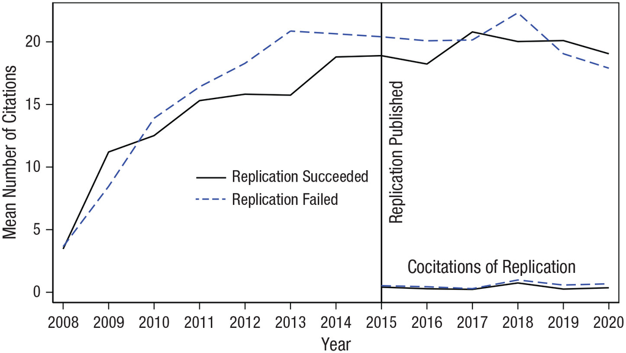

von Hippel (2022): (1.) replication failure reduced citations of the target studies by about 9% (2.) less than 3% of citations of original studies co-cited the replication study

## Citations before and after successful and failed replications

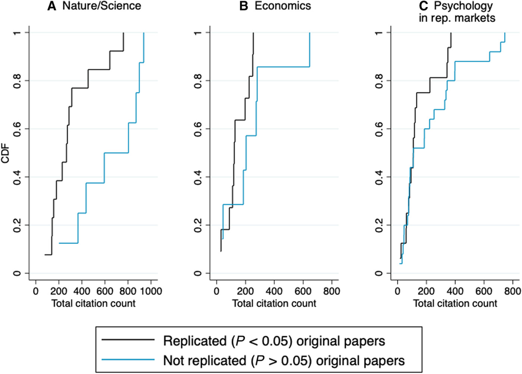

Serra-Garcia & Gneezy (2021): Studies that fail to replicate are cited more than those that are replicable

## Why do replication failures have so little impact?

von Hippel (2022):

1. Confirmation bias among researchers
   - Tendency to seek out, favor, and remember information that supports what you already believe
2. Confirmation bias built into search engines
   - Google Scholar ranks documents more highly that have been cited more often
   - A “classic” article will be cited more and so rank higher than a more recent (failed) replication

## Loss-of-Confidence Project

Rohrer et al. (2021): Usually, self-correction is understood to be an outcome of the activities of the scientific community

- Reviewers and editors catch errors before studies get published
- Critical readers write commentaries when they spot flaws in somebody else’s reasoning
- Replications by impartial groups of researchers allow the scientific community to update their beliefs about the likelihood that a scientific claim is true

## Loss-of-Confidence Project

It is less common to see cases where researchers publicly acknowledge out errors in their *own* studies or question their *own* conclusions

- Rohrer et al. (2021) invited psychological researchers to submit statements describing findings that they had published and in which they had subsequently lost confidence

## Loss-of-Confidence Project

Rohrer et al. (2021):

- Five of the statements reported methodological errors, including misspecified statistical models
- Four of the statements reported invalid inferences, including because of problems of validity
- Seven of the statements reported some kind of p-hacking (recognized in retrospect)

## Responding to errors in the work of oneself and others

Bishop (2018): we scientists are human, we make mistakes — How should we respond to errors?

- Retractions: withdrawing work
- Postpublication critiques leading to corrections

**Tip**

- PubPeer https://pubpeer.com/: commentators can be anonymous
- Retraction Watch https://retractionwatch.com: tracks article retractions

## How should we respond to errors?

**Some good advice**

Bishop (2018):

- We should never use mockery or personal abuse against other scientists who make honest errors
- Nor should we assume that failure to replicate a result is a sign of poor science in the original study
  - It is an indication that more work needs to be done to establish whether, and under what conditions, the result is robust
- Criticism is the bedrock of the scientific method. It should not be personal
  - If one has to point to problems then this should be done without implying that the person is stupid or dishonest

If wrong ideas or results are not challenged, we let down future generations

## Activate

Our learning questions then are these:

**Activate**

- Is science self-correcting?
- Why, when, and how do corrections happen?
- What is *your* response to error?

## The evaluation of science and scientists

**What we can do**

- Citation data has become critical to the evaluation of science and of scientists
- What does the analysis of citation data show us?

## Remember our ideals

Who does what? Does it matter who you are? In a sense, it *should not* matter.

Merton (1942) says:

> The acceptance or rejection of claims … is not to depend on the personal attributes of their protagonist [of who you are, your] race, nationality, class and personal qualities …

Likewise

> careers [should be] open to talents [no matter who you are]

## Bibliometrics and the science of science

There is a long tradition in the science of science that uses citation networks and text analysis of scientific papers (Gomez et al., 2022)

- to embody the flow of ideas in science
- map its structure
- map the distribution and spread of knowledge

## Bibliometrics and the science of science

Fortunato et al. (2018) use an analysis of indexed articles and a large-scale analysis of text to conclude that whereas the number of publications grows exponentially, the space of ideas expands only linearly

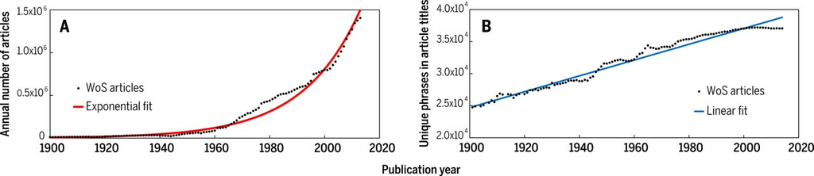

Fortunato et al. (2018): (A) Annual production of scientific articles indexed in the WoS database. (B) Growth of ideas covered by articles indexed in the WoS.

## We can conduct analyses to reveal inequities or biases

Lerman et al. (2022):

- Women are less likely than their male peers to be mentored by eminent faculty
- Women are less likely to be hired and promoted
- Women publish in less prestigious journals
- Women have fewer collaborators
- Women are underrepresented among journal reviewers and editors
- Womens’ papers receive fewer citations

## Intersectional inequities

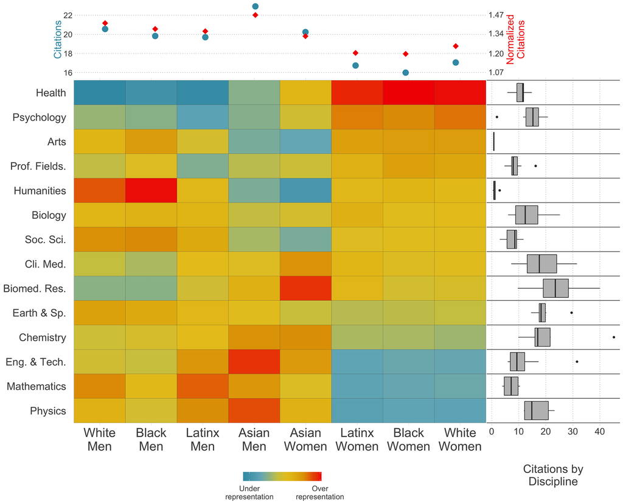

Kozlowski et al. (2022) analyzed about 7 million articles to find *gender and ethnicity* disparities in who does what science

## Biases and inequities: gender and ethnicity

- Kozlowski et al. (2022)’s results show:
  - While White authors publish everywhere, *a privilege of choice*,
  - Minoritized authors tend to publish in scientific disciplines and on research topics that reflect their gendered and racialized social identities
- Unequal representation in science leads to underinvestigation of particular topics and may block innovation

## Biases and inequities: gender

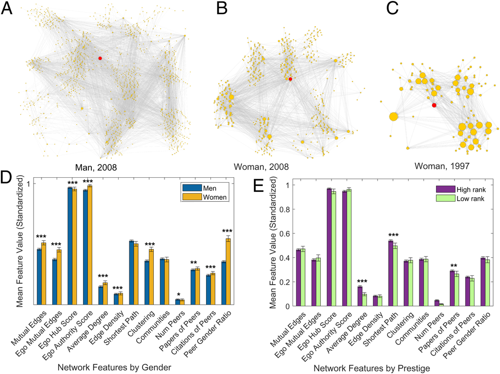

Lerman et al. (2022) studied prominent scholars who were elected to the National Academy of Sciences, constructing author citation networks that capture the structure of recognition among peers: gender differences in the structure of citations networks

## Biases and inequities: geography

There is a brutal geography at work: whose ideas get heard?

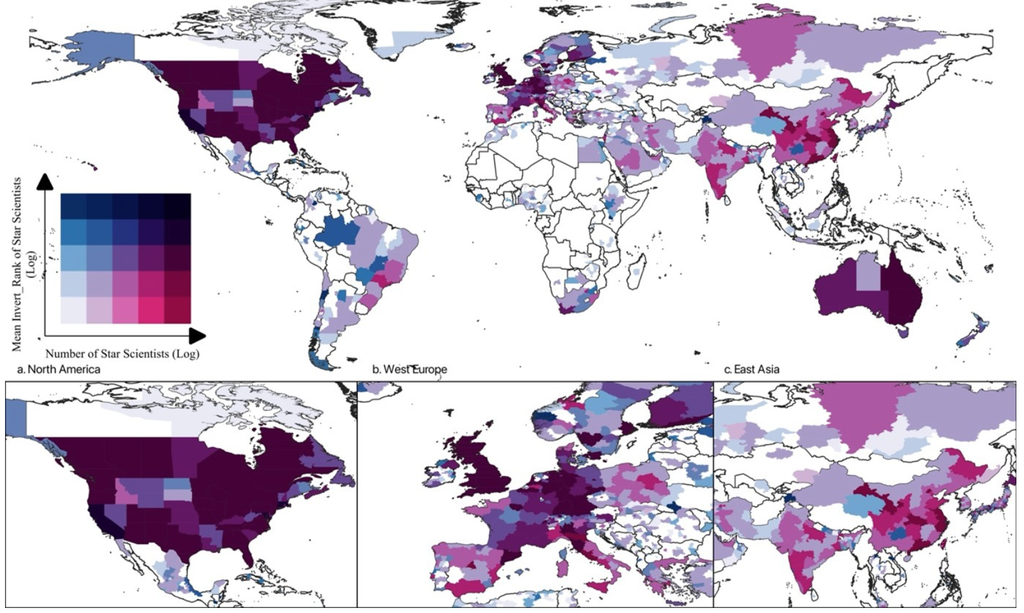

Rodríguez-Pose et al. (2026): For much of the emerging world, the map of frontier research is close to empty

## Biases and inequities: geography

Gomez et al. (2022): research can make an impact only if it is visible

- Journal prestige, scientific reputation and study quality shape visibility
- But consider also country factors:
  - Funding impacts: history, scale and quality of research, library subscriptions
  - Countries with advantages probably receive additional citations for their research, over and above what one would expect just from the subject matter

## Geographic distortion effects

- Gomez et al. (2022):
  - the number of countries represented in the global scientific conversation is increasing
  - the extent to which work is visible and valued may be highly stratified by country

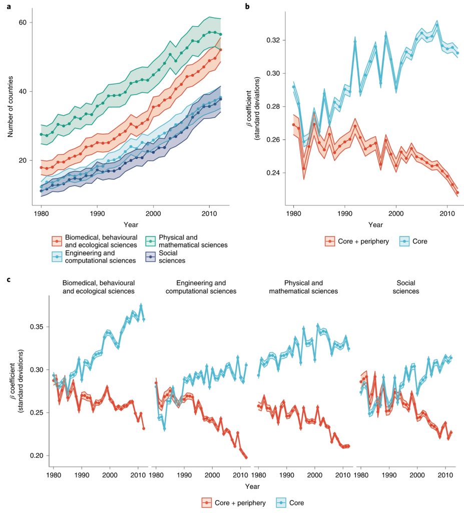

Gomez et al. (2022): leading countries in global science increasingly receive more citations than other countries doing similar research

## Nobody needs to intend to do anything: effects of *homophily*

- Zumel Dumlao & Teplitskiy (2025):
  - if reviewers typically favor work from their own country (homophily)
  - and most reviewers come from just a few countries
  - then authors from those countries enjoy a structural advantage

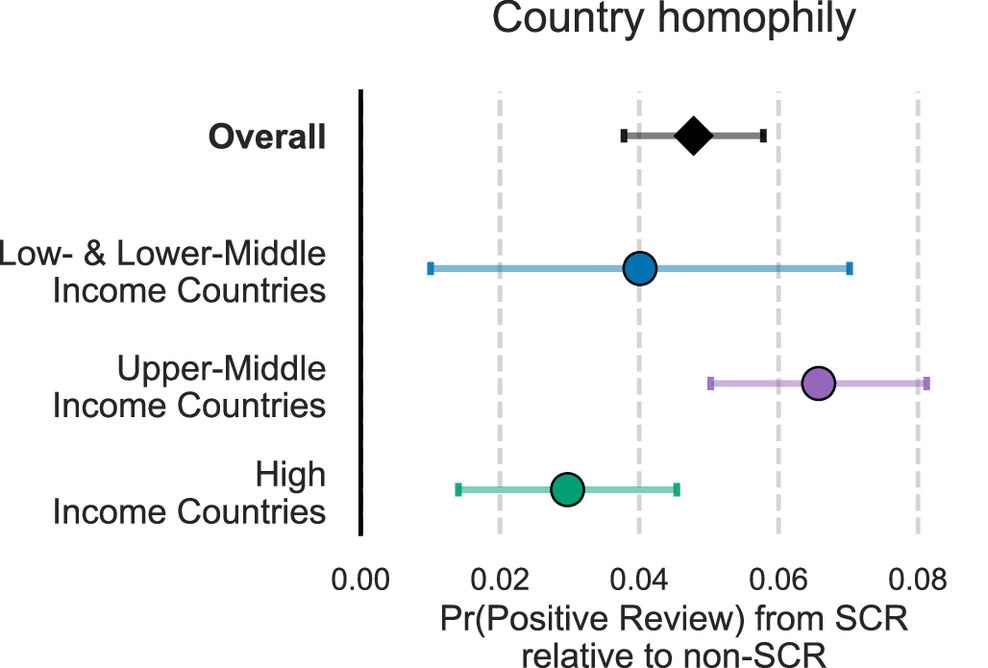

Zumel Dumlao & Teplitskiy (2025): same country reviewers (SCRs) are more likely to give positive reviews compared to non-SCRs on the same manuscript

## Activate

Our learning questions then are these:

**Activate**

- If citation data reveal inequities or biases, what can we do about this?
  - How do we ensure that our sense of who does science or what science there is engages with these limitations?
  - How can we overcome such limitations in our search, review and citation practices?

## Activate

Our learning questions overall are:

**Activate**

- When, why, and how do you do scholarly citation?
- How does science (peer review) work?
- Is science self-correcting?
- What do citations reflect or reveal about science and scientists?
  - How do you develop your own position?

## References

Aczel, B., Szaszi, B., & Holcombe, A. O. (2021). A billion-dollar donation: Estimating the cost of researchers’ time spent on peer review. *Research Integrity and Peer Review*, *6*(1). https://doi.org/10.1186/s41073-021-00118-2

Alberts, B., Cicerone, R. J., Fienberg, S. E., Kamb, A., McNutt, M., Nerem, R. M., Schekman, R., Shiffrin, R., Stodden, V., Suresh, S., Zuber, M. T., Pope, B. K., & Jamieson, K. H. (2015). Self-correction in science at work. *Science*, *348*(6242), 1420–1422. https://doi.org/10.1126/science.aab3847

Allchin, D. (2026). When is science “self-correcting”? *Studies in History and Philosophy of Science*, *119*, 102216. https://doi.org/10.1016/j.shpsa.2026.102216

Allen, L., Scott, J., Brand, A., Hlava, M., & Altman, M. (2014). Publishing: Credit where credit is due. *Nature*, *508*(7496), 312–313. https://doi.org/10.1038/508312a

Association, A. P. (2020). *Publication Manual of the American Psychological Association* (7th ed.). American Psychological Association. https://apastyle.apa.org/products/publication-manual-7th-edition

Bak-Coleman, J., Mann, R. P., West, J., & Bergstrom, C. T. (2022). Replication does not measure scientific productivity. *SocArXiv, Doi*, *10*, 8. https://doi.org/DOI: 10.31235/osf.io/rkyf7

Bak-Coleman, J., Mann, R., Bergstrom, C., Gross, K., & West, J. (2022). *Revisiting the replication crisis without false positives*. https://osf.io/rkyf7_v1

Bakker, M., & Wicherts, J. M. (2011). The (mis)reporting of statistical results in psychology journals. *Behavior Research Methods*, *43*(3), 666–678. https://doi.org/10.3758/s13428-011-0089-5

Baxt, W. G., Waeckerle, J. F., Berlin, J. A., & Callaham, M. L. (1998). Who reviews the reviewers? Feasibility of using a fictitious manuscript to evaluate peer reviewer performance. *Annals of Emergency Medicine*, *32*(3), 310–317. https://doi.org/10.1016/S0196-0644(98)70006-X

Bishop, D. V. M. (2018). Fallibility in Science: Responding to Errors in the Work of Oneself and Others. *Dvances in Methods and Practices in Psychological Science*, *1*(3), 432–438. https://doi.org/doi:10.1177/2515245918776632

Brembs, B. (2018). Prestigious science journals struggle to reach even average reliability. *Frontiers in Human Neuroscience*, *12*. https://doi.org/10.3389/fnhum.2018.00037

Brembs, B., Button, K., & Munafò, M. (2013). Deep impact: Unintended consequences of journal rank. *Frontiers in Human Neuroscience*, *7*. https://doi.org/10.3389/fnhum.2013.00291

Bright, L. K. (2017). On fraud. *Philosophical Studies*, *174*(2), 291–310. https://doi.org/10.1007/s11098-016-0682-7

Buzbas, E. O., & Devezer, B. (2026, September 30). *The Difference Between "Replicable" and "Not Replicable" Is Not Itself Scientifically Replicable*. https://doi.org/10.48550/arXiv.2604.26268

Case, D. O., & Higgins, G. M. (2000). How can we investigate citation behavior? A study of reasons for citing literature in communication. *Journal of the American Society for Information Science*, *51*(7), 635–645. https://doi.org/10.1002/(SICI)1097-4571(2000)51:7<635::AID-ASI6>3.0.CO;2-H

Collaboration, O. S. et al. (2015). Estimating the reproducibility of psychological science. *Science*, *349*(6251), aac4716. https://doi.org/DOI: 10.1126/science.aac4716

Corneille, O., Havemann, J., Henderson, E. L., IJzerman, H., Hussey, I., Orban de Xivry, J.-J., Jussim, L., Holmes, N. P., Pilacinski, A., Beffara, B., Carroll, H., Outa, N. O., Lush, P., & Lotter, L. D. (2023). Beware “persuasive communication devices” when writing and reading scientific articles. *eLife*, *12*, e88654. https://doi.org/10.7554/eLife.88654

Deer, B. (2011). How the case against the MMR vaccine was fixed. *BMJ*, *342*, c5347. https://doi.org/10.1136/bmj.c5347

Devezer, B., Navarro, D. J., Vandekerckhove, J., & Ozge Buzbas, E. (2021). The case for formal methodology in scientific reform. *Royal Society Open Science*, *8*(3), 200805. https://doi.org/10.1098/rsos.200805

Erikson, M. G., & Erlandson, P. (2014). A taxonomy of motives to cite. *Social Studies of Science*, *44*(4), 625–637. https://doi.org/10.1177/0306312714522871

Fortunato, S., Bergstrom, C. T., Börner, K., Evans, J. A., Helbing, D., Milojević, S., Petersen, A. M., Radicchi, F., Sinatra, R., Uzzi, B., Vespignani, A., Waltman, L., Wang, D., & Barabási, A.-L. (2018). Science of science. *Science*, *359*(6379), eaao0185. https://doi.org/10.1126/science.aao0185

Garfield, E. (1955). Citation Indexes for Science. *Science*, *122*(3159), 108–111. https://www.science.org/doi/10.1126/science.122.3159.108

Gigerenzer, G. (1993). The superego, the ego, and the id in statistical reasoning. In *A handbook for data analysis in the behavioral sciences: Methodological issues* (pp. 311–339). Lawrence Erlbaum Associates, Inc.

Godlee, F., Gale, C. R., & Martyn, C. N. (1998). Effect on the quality of peer review of blinding reviewers and asking them to sign their reports. *JAMA*, *280*(3), 237. https://doi.org/10.1001/jama.280.3.237

Gomez, C. J., Herman, A. C., & Parigi, P. (2022). Leading countries in global science increasingly receive more citations than other countries doing similar research. *Nature Human Behaviour*, *6*(7), 919–929. https://doi.org/10.1038/s41562-022-01351-5

Heesen, R., & Kofi Bright, L. (2021). Is peer review a good idea? | the british journal for the philosophy of science: Vol 72, no 3. *The British Journal for the Philosophy of Science*, *72*(3). https://www.journals.uchicago.edu/doi/10.1093/bjps/axz029

Holcombe, A. O., Kovacs, M., Aust, F., & Aczel, B. (2020). Documenting contributions to scholarly articles using CRediT and tenzing. *PLOS ONE*, *15*(12), e0244611. https://doi.org/10.1371/journal.pone.0244611

Hubbard, R. (2004). Alphabet Soup: Blurring the Distinctions Betweenp’s anda’s in Psychological Research. *Theory & Psychology*, *14*(3), 295–327. https://doi.org/10.1177/0959354304043638

Kozlowski, D., Larivière, V., Sugimoto, C. R., & Monroe-White, T. (2022). Intersectional inequalities in science. *Proceedings of the National Academy of Sciences*, *119*(2), e2113067119. https://doi.org/10.1073/pnas.2113067119

Kuhn, T. S. (1970). *The structure of scientific revolutions* ([2d ed., enl). University of Chicago Press.

Larivière, V., Pontille, D., & Sugimoto, C. R. (2021). Investigating the division of scientific labor using the Contributor Roles Taxonomy (CRediT). *Quantitative Science Studies*, *2*(1), 111–128. https://doi.org/10.1162/qss_a_00097

Lerman, K., Yu, Y., Morstatter, F., & Pujara, J. (2022). Gendered citation patterns among the scientific elite. *Proceedings of the National Academy of Sciences*, *119*(40), e2206070119. https://doi.org/10.1073/pnas.2206070119

Longino, H. (2026). The Social Dimensions of Scientific Knowledge. In E. N. Zalta & U. Nodelman (Eds.), *The Stanford encyclopedia of philosophy* (Fall 2026). https://plato.stanford.edu/archives/fall2026/entries/scientific-knowledge-social/; Metaphysics Research Lab, Stanford University.

Makel, M. C., Plucker, J. A., & Hegarty, B. (2012). Replications in Psychology Research: How Often Do They Really Occur? *Perspectives on Psychological Science*, *7*(6), 537–542. https://doi.org/10.1177/1745691612460688

Mastroianni, A. (2022). *The rise and fall of peer review: Why the greatest scientific experiment in history failed, and why that’s a great thing*. https://www.experimental-history.com/p/the-rise-and-fall-of-peer-review

Meehl, P. E. (1990). Why summaries of research on psychological theories are often uninterpretable. *Psychological Reports*, *66*(1), 195–244. https://doi.org/10.2466/pr0.1990.66.1.195

Merton, R. K. (1942). A Note on Science and Democracy. *Journal of Legal and Political Sociology*, *1*(1 and 2), 115–126.

Merton, R. K. (1957). Priorities in Scientific Discovery: A Chapter in the Sociology of Science. *American Sociological Review*, *22*(6), 635–659. https://doi.org/10.2307/2089193

Mill, J. S. (1859). *On Liberty* (Reprinted 1974, 1982). Penguin. (Original work published John W. Parker and Son)

Nuijten, M. B., Hartgerink, C. H. J., van Assen, M. A. L. M., Epskamp, S., & Wicherts, J. M. (2016). The prevalence of statistical reporting errors in psychology (1985–2013). *Behavior Research Methods*, *48*(4), 1205–1226. https://doi.org/10.3758/s13428-015-0664-2

Nuijten, M. B., & Wicherts, J. M. (2024). Implementing Statcheck During Peer Review Is Related to a Steep Decline in Statistical-Reporting Inconsistencies. *Advances in Methods and Practices in Psychological Science*, *7*(2), 25152459241258945. https://doi.org/10.1177/25152459241258945

Peterson, D. (2016). The Baby Factory: Difficult Research Objects, Disciplinary Standards, and the Production of Statistical Significance. *Socius*, *2*, 2378023115625071. https://doi.org/10.1177/2378023115625071

Pierce, C. S. (1958). How to make our ideas clear. In *Selected writings* (pp. 114–136). Dover Publications. (Original work published 1878)

Popper, K. (2005). *The logic of scientific discovery* (2nd ed.). Routledge. https://doi.org/10.4324/9780203994627

Rakow, T. (2026). Estimating the Prevalence of Replication Research Is Challenging, Not Least Because Even a Thorough Database Search Can Be Shallow. *Perspectives on Psychological Science*, 17456916261452961. https://doi.org/10.1177/17456916261452961

Richardson, R. A. K., Hong, S. S., Byrne, J. A., Stoeger, T., & Amaral, L. A. N. (2025). The entities enabling scientific fraud at scale are large, resilient, and growing rapidly. *Proceedings of the National Academy of Sciences*, *122*(32), e2420092122. https://doi.org/10.1073/pnas.2420092122

Rodríguez-Pose, A., Xiang, L., & Lee, N. (2026, January 26). *The brutal geography of global elite scientific research - LSE Impact*. LSE Impact - Understanding impact; practice in academic research. https://blogs.lse.ac.uk/impactofsocialsciences/2026/01/26/the-brutal-geography-of-global-elite-scientific-research/

Rohrer, J. M., Tierney, W., Uhlmann, E. L., DeBruine, L. M., Heyman, T., Jones, B., Schmukle, S. C., Silberzahn, R., Willén, R. M., Carlsson, R., Lucas, R. E., Strand, J., Vazire, S., Witt, J. K., Zentall, T. R., Chabris, C. F., & Yarkoni, T. (2021). Putting the Self in Self-Correction: Findings From the Loss-of-Confidence Project. *Perspectives on Psychological Science*, *16*(6), 1255–1269. https://doi.org/10.1177/1745691620964106

Scheel, A. M. (2022). Why most psychological research findings are not even wrong. *Infant and Child Development*, *31*(1), e2295. https://doi.org/10.1002/icd.2295

Schroter, S., Black, N., Evans, S., Godlee, F., Osorio, L., & Smith, R. (2008). What errors do peer reviewers detect, and does training improve their ability to detect them? *Journal of the Royal Society of Medicine*, *101*(10), 507–514. https://doi.org/10.1258/jrsm.2008.080062

Serra-Garcia, M., & Gneezy, U. (2021). Nonreplicable publications are cited more than replicable ones. *Science Advances*, *7*(21), eabd1705. https://doi.org/10.1126/sciadv.abd1705

Shalizi, C. (n.d.). *If peer review did not exist, we would have to invent something very like it to serve highly similar ends*. Retrieved https://bactra.org/weblog/916.html

Smaldino, P. E., & McElreath, R. (2016). The natural selection of bad science. *Royal Society Open Science*, *3*(9), 160384. https://doi.org/10.1098/rsos.160384

Smaldino, P. E., & O’Connor, C. (2022). Interdisciplinarity can aid the spread of better methods between scientific communities. *Collective Intelligence*, *1*(2), 26339137221131816. https://doi.org/10.1177/26339137221131816

Vazire, S., & Holcombe, A. O. (2022). Where Are the Self-Correcting Mechanisms in Science? *Review of General Psychology*, *26*(2), 212–223. https://doi.org/10.1177/10892680211033912

von Hippel, P. T. (2022). Is Psychological Science Self-Correcting? Citations Before and After Successful and Failed Replications. *Perspectives on Psychological Science*, *17*(6), 1556–1565. https://doi.org/10.1177/17456916211072525

Wakefield, A. J., Murch, S. H., Anthony, A., Linnell, J., Casson, D. M., Malik, M., Berelowitz, M., Dhillon, A. P., Thomson, M. A., Harvey, P., Valentine, A., Davies, S. E., & Walker-Smith, J. A. (1998). RETRACTED: Ileal-lymphoid-nodular hyperplasia, non-specific colitis, and pervasive developmental disorder in children. *The Lancet*, *351*(9103), 637–641. https://doi.org/10.1016/S0140-6736(97)11096-0

Ward-Fear, G., Pauly, G. B., Vendetti, J. E., & Shine, R. (2020). Authorship Protocols Must Change to Credit Citizen Scientists. *Trends in Ecology & Evolution*, *35*(3), 187–190. https://doi.org/10.1016/j.tree.2019.10.007

Whamond, A., Vazire, S., Clarke, B., Moodie, N., Schiavone, S., Thibault, R. T., & Hardwicke, T. E. (2025). How Do Psychology Journals Handle Postpublication Critique? A Cross-Sectional Study of Policy and Practice. *Advances in Methods and Practices in Psychological Science*, *8*(3), 25152459251366102. https://doi.org/10.1177/25152459251366102

Zumel Dumlao, J. M., & Teplitskiy, M. (2025). Geographical diversity of peer reviewers shapes author success. *Proceedings of the National Academy of Sciences*, *122*(33), e2507394122. https://doi.org/10.1073/pnas.2507394122